# Post hoc inference for differential gene expression studies

This vignette illustrates the use of post hoc inference methods for differential expression studies in genomics

Pierre Neuvial https://math.univ-toulouse.fr/~pneuvial (Institut de Mathématiques de Toulouse)https://math.univ-toulouse.fr  
2020-06-22

# Introduction

We recall the classical paradigm of False Discovery Rate control for differential gene expression studies, and pinpoint intrinsic limitations to this paradigm. Then we briefly introduce the framework of post hoc inference, which aims at addressing these limitations. The applicative example is taken from Blanchard, Neuvial, and Roquain (2019).

The methods presented in this document are implemented in the development version of the R package `sansSouci`, which is available from github:

```r
remotes::install_github("pneuvial/sanssouci@develop")
```

```r
library("sansSouci")
```

## Motivation: a differential gene expression study

```r
data_url <- url("https://plmbox.math.cnrs.fr/f/755496cc4c154a6dbab0/?dl=1")
dat <- readRDS(data_url)
```

This data set which consists of gene expression measurements for $n = 79$ patients with B-cell acute lymphoblastic leukemia (ALL) Chiaretti et al. (2004),Chiaretti et al. (2005). These patients are classified into two subgoups, depending on whether or not they harbor a specific mutation called “BCR/ABL”:

```r
table(colnames(dat))
```

```
BCR/ABL     NEG
     37      42
```

```r
mut <- "BCR/ABL"
```

The goal of this study is to understand the molecular differences at the gene expression level between the populations of BCR/ABL positive and negative (“NEG”) patients. For each patient, we observe a vector of 12625 gene expression values.

The most basic question to ask is:

> For which genes is there a difference in the mean expression level of the mutated and non-mutated population?

This question can be addressed by performing one statistical test of no difference between means for each gene, and to define “differentially expressed” genes as those passing some significance threshold. One important concern here is the calibration of the significance threshold.

## Classical differential analysis

We start with a simple Welch test for differential expression for each gene. This can be done e.g. using the `sansSouci::rowWelchTests` function:

```r
categ <- ifelse(colnames(dat) == "BCR/ABL", 1, 0) # map to 0/1
rwt <- sansSouci::rowWelchTests(dat, categ)
class(rwt) <- "list"
dex <- as.data.frame(rwt)
rm(rwt)
pval <- dex[["p.value"]]
```

We plot a histogram of the corresponding $p$-values:

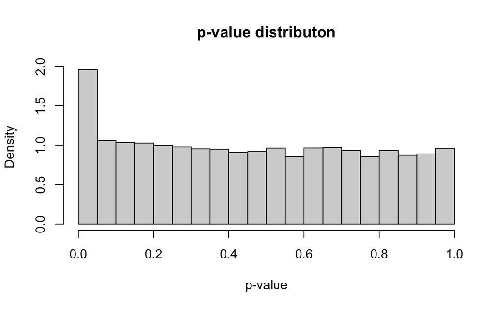

```r
hist(pval, probability = TRUE, breaks = 20,
     xlab = "p-value", main = "p-value distributon")
```

As expected, the distribution presents a large number of small $p$-values (which include signals, i.e. differentially expressed genes) mixed with uniformly distributed $p$-values (corresponding to non-differentially expressed genes). Accordingly, the $p$-values are transformed into a standard normal scale, the density of these statistics (in red) deviates from the standard normal distribution:

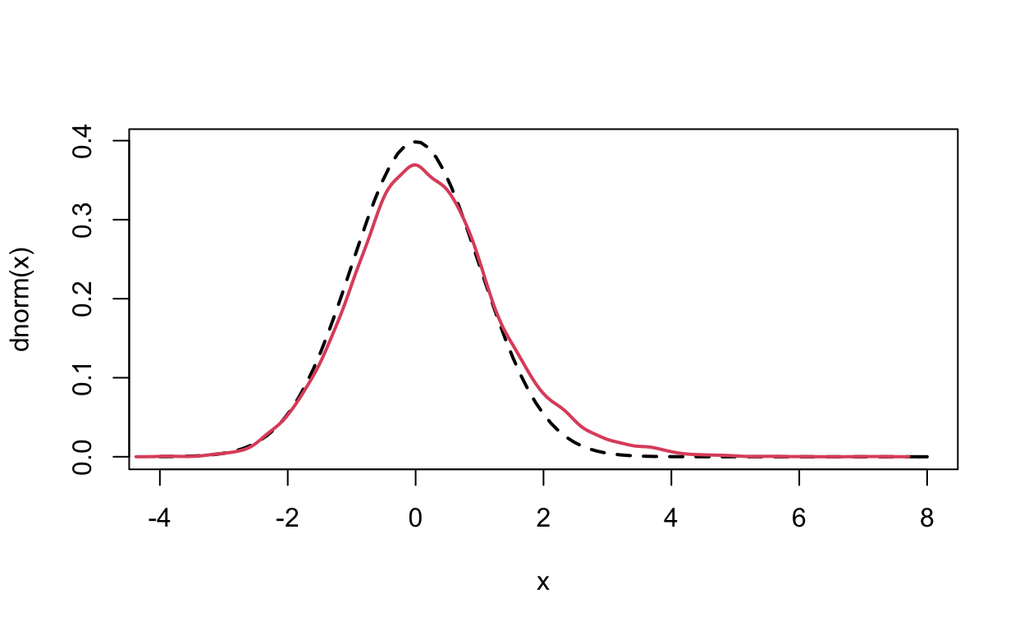

```r
stat <- qnorm(1 - pval)
curve(dnorm, -4, 8, lty = 2, lwd = 2)
lines(density(stat), col = 2, lwd = 2)
```

### Multiple testing correction: False Discovery Rate control

The state of the art approach to large-scale multiple testing is to control the False Discovery Rate (FDR), which is the expected proportion of wrongly selected genes (false positives) among all selected genes Benjamini and Hochberg (1995). The most widely used method to control this risk is the Benjamini-Hochberg (BH) procedure, which has been shown to control the FDR when the hypotheses corresponding to the non-differentially expressed genes are independent Benjamini and Hochberg (1995) or satisfy a specific type of positive dependence called Positive Regression Dependence on the Subset $\mathcal{H}_0$ of truly non-differentially expressed genes Benjamini and Yekutieli (2001).

```r
q <- 0.05
adjp.BH <- p.adjust(pval, method = "BH")
nBH <- sum(adjp.BH <= q)
dex$adjp.BH <- adjp.BH
```

|  | statistic | parameter | p.value | meanDiff | adjp.BH |
| --- | --- | --- | --- | --- | --- |
| 1636_g_at | 9.130386 | 68.71654 | 1.791900e-13 | 1.1000116 | 2.262274e-09 |
| 39730_at | 8.604144 | 71.47272 | 1.206368e-12 | 1.1525269 | 7.615200e-09 |
| 1635_at | 7.167919 | 67.92078 | 7.102754e-10 | 1.2026753 | 2.989076e-06 |
| 1674_at | 6.737666 | 61.99641 | 6.105794e-09 | 1.4272115 | 1.927141e-05 |
| 40202_at | 6.330859 | 72.59220 | 1.797179e-08 | 1.7793784 | 4.537877e-05 |
| 40504_at | 6.413755 | 61.44329 | 2.272148e-08 | 1.1810295 | 4.780979e-05 |
| 37027_at | 5.709362 | 76.87422 | 2.031131e-07 | 1.3487023 | 3.663289e-04 |
| 37015_at | 5.919240 | 47.46351 | 3.453568e-07 | 1.0327017 | 5.450161e-04 |
| 32434_at | 5.645085 | 62.70762 | 4.267680e-07 | 1.6785501 | 5.986607e-04 |
| 40167_s_at | 5.508733 | 74.83536 | 4.884438e-07 | 0.7448175 | 6.166604e-04 |

[output cut: 153 more lines]

## Caveats of FDR control

### Caveat 1: FDR control prescribes a list of significant genes

In this data set, 163 genes are called differentially expressed at a False Discovery Rate (FDR) of $q = 0.05$. An investigator given such a list will generally be interested in refined and/or interpreting this list by combining it with on the problem at hand. For example, the investigator may not be interested in genes whose global expression level is small, or they may be interested in only a subset $S$ of the list, or they may be interested in combining such an $S$ with other genes which are below the significance threshold, but share some biological properties with the genes of $S$. Unfortunately, *FDR control on the list provides no guarantee on such user-refined gene lists*.

# Post hoc inference

In order to address these important limitations, Goeman and Solari (2011) have popularized the concept of “post hoc inference”. This approach elaborates on the theory of multiple testing in order to build confidence bounds on *arbitrary* subsets of hypotheses. Formally, let $\mathcal{H}$ be a set of $m$ null hypotheses, and $\mathcal{H}_0$ be the (unknown) subset of true null hypotheses. Then for $S \subset \mathcal{H}$, $|S \cap \mathcal{H}_0|$ is the number of false positives in $S$. With this notation, $\overline{V}$ is a post hoc upper bound at confidence level $\alpha$ if

$$\mathbb{P}(\forall S \subset \mathcal{H}, \quad |S \cap \mathcal{H}_0| \leq \overline{V}(S)) \geq 1-\alpha$$
That is, there exists an event of probability $1-\alpha$ such that *for any subset $S$ of hypotheses* -possibly data-driven or cherry-picked by a user, the number of false positives in $S$ is less than $V(S)$.

Post hoc inference may seem an excessively ambitious goal. Following earlier works by Genovese and Wasserman (2006), Goeman and Solari (2011) have proposed a general framework based on closed testing in order to build such bounds. In particular, they provide such a bound in the case where the tested hypotheses satisfy the PRDS assumption (that is, under the same assumptions as those under which FDR control is valid). We refer to Sarkar (1998) for a formal definition of PRDS. It was later shown in Blanchard, Neuvial, and Roquain (2020) that such post hoc bounds can be obtained as a consequence of the control of a multiple testing risk called the Joint Error Rate (JER). In particular, under PRDS, they recover the bound of Goeman and Solari (2011) under PRDS as a corollary of the Simes inequality Simes (1986), a probabilistic inequality that plays an important role in multiple testing.

Our goal is to illustrate two main points:

1. the general interest of such post-hoc bounds, by showing that they provide an investigator with interpretable and practically useful
2. the fact that improved bounds (with respect to the original Goeman and Solari (2011) bounds) may be improved in the specific case of two-sample tests for differential gene expression studies.

# Confidence envelopes on “top-$k$” lists

In the absence of prior information on genes, a natural idea is to rank them by decreasing statistical significance, and a natural question to ask is: can we provide a lower confidence envelope on the number (or proportion) of truly differentially expressed genes among the “top $k$” genes, for a user-defined $k$?

We illustrate the use of post-hoc methods to provide this type of information. More specifcally, we build confidence statements on the number of true/false positives within the top $k$ most significant genes in a differential gene expression study, where $k$ may be defined by the user after seing the data, and multiple choices of $k$ are allowed.

We start by defining a target confidence level:

```r
alpha <- 0.1
```

The method of Goeman and Solari (2011) makes it possible to calculate a confidence envelope on the number of true positives among the most significant genes:

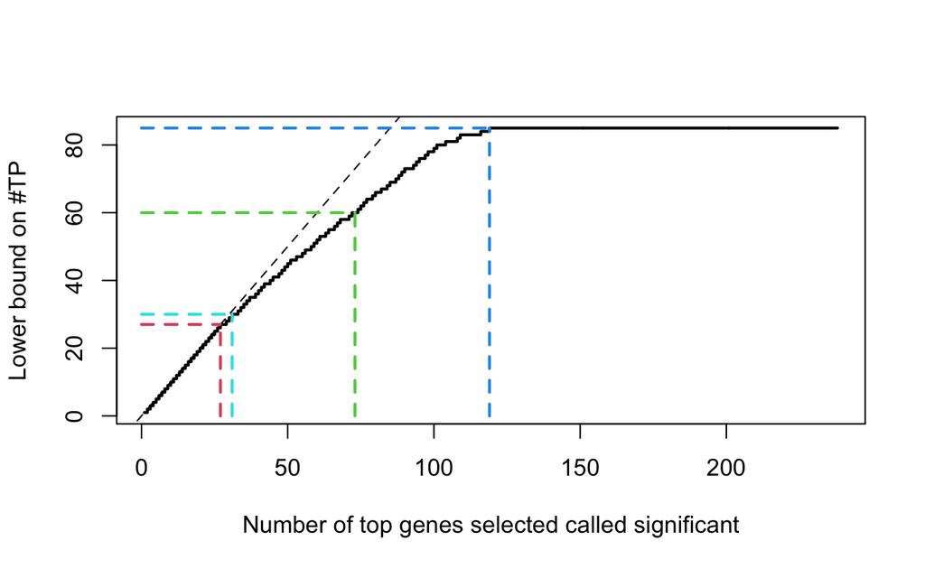

The above plot should be interpreted as follows: among the 73 most significant genes (ie those with smallest $p$-value), we can guarantee with 90% confidence that the proportion of true positives is larger than 60, or equivalently, that the proportion of true positives is larger than 0.8.

Importantly, this guarantee holds *simultaneously* for all possible choices for the number of top genes. That is, we can for example guarantee with 90% confidence that the following statements hold simultaneously:

- among the top 27 genes, there is no false positive;
- among the top 73 genes, the number of true positives is larger than 60;
- among the top 119 genes, the number of true positives is larger than 85.

## Comparison to FDR control

Let us compare this with the result of the classical approach based on False Discovery Rate control.

### Interpretability of the output of a FDR controlling procedure

The first 163 genes are called differentially expressed. The above post hoc approach ensures with 90% confidence that the proportion of false positives in this list is less than 0.5. This is a probabilistic statement about this particular list.

In contrast, FDR control guarantees that the proportion of false positives among the first 163 genes is less than 0.05. This is a statement *on average over hypothetical replications of this gene expression study*, which therfore has limited interpretability.

Note that this is limitation of the interpretability of FDR controlling procedures in general, which is by no means specific to the BH procedure.

### Post hoc choice of the number of top genes

The above figure shows that the lower bound on the number of true positives is constant (equal to 85) after 119 genes. This indicates that choosing the top 163 genes, as suggested by the BH procedure, may not be the best choice for this data set. A very appealing feature of the post hoc approach is that it lets the user of the procedure choose the number of top genes that they will consider *after the data analysis is performed* (hence the name *post hoc*). In this particular example, a user can choose *after looking at the above plot* between reporting first 27 genes (among which with high probability, there is no false positive ), and the first 119 genes (among which with high probability, there are at most 34 false positives, ie the FDP is less than 0.29%). If the user is interested in a list in which the proportion of false positives is less than 0.05 with high probability, then they can read from the above plot that the top 31 genes have this property.

In contrast, the FDR approach is not post hoc. Specifically, once the BH procedure has been applied at a given level, the only information we have is about one single list of 163 genes. In particular, if we are interested in “top $k$” lists with $k \neq$ 163, the only thing we can say is that the FDR in a list with $k <$ 163 is less than 0.05, and that the FDR in a list with $k >$ 163 is larger than 0.05.

# Inference on data-driven sets of genes

In this section we illustrate how post hoc inference may be used to provide confidence statements on the number of true/false positives within sets of genes selected in a data-driven way, e.g. by penalized linear regression methods such as the Lasso or Elastic net.

## Penalized logistic regression

We apply logistic lasso and elastic net regression in order to identify a subset of genes that can predict the “BCR/ABL” vs “NEG” status of a patient from their expression level.

```r
library("glmnet")
y <- colnames(dat)
x <- t(dat)
fitL <- glmnet(x, y, alpha = 1, family = "binomial")
fitE <- glmnet(x, y, alpha = 0.5, family = "binomial")
```

Below are shown the regularization paths of the Lasso and Elastic net.

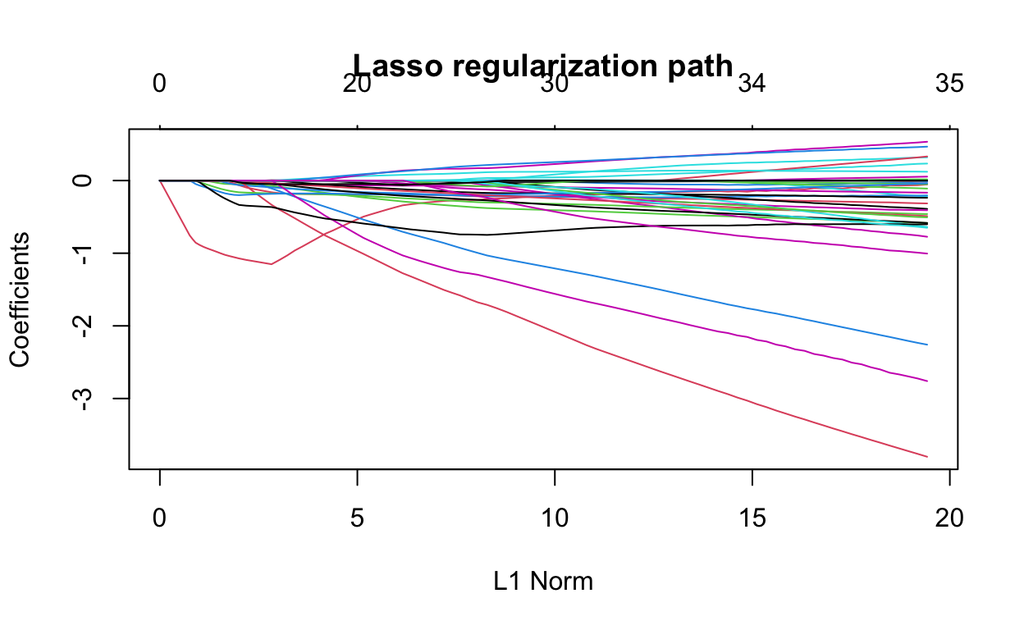

```r
plot(fitL, main = "Lasso regularization path")
```

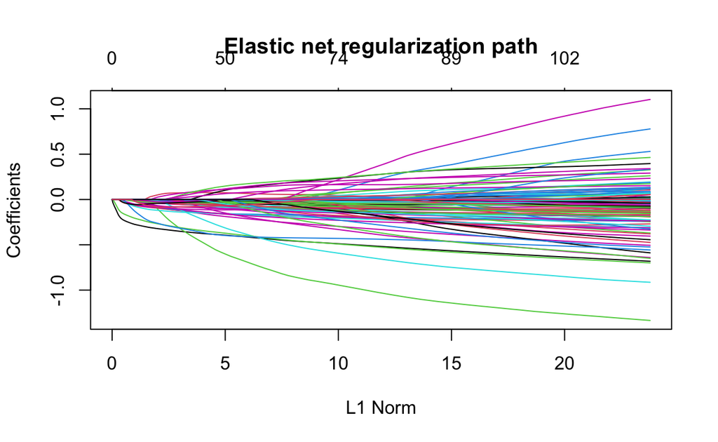

```r
plot(fitE, main = "Elastic net regularization path")
```

## Confidence envelopes on regularization paths

Here, we use the post hoc approach introduced by Goeman and Solari (2011) to calculate, for each point in the Lasso and Elastic net regularization paths, the bounds on the number of true/false positives associated to the corresponding active set.

The function below returns the desired bounds from the output of the `glmnet` package:

```r
RSbar <- function(pred, fit) {
  beta <- fit$beta
  non0 <- colSums(beta != 0)
  ww <- max(which(non0 <= pred))
  ids <- which(beta[, ww] != 0)
  Sbar <- posthocBySimes(pval, select = ids, alpha = 0.05)
  c(R = length(ids), Sbar = Sbar) #, FDPbar = (R - Sbar)/max(R, 1)
}
```

We focus on the first variables in the active set:

```r
npred <- 30
```

```r
stats <- sapply(1:npred, RSbar, fitL)
stats <- data.frame(Sbar = stats["Sbar", ], R = stats["R", ])
stats$FDPbar <- (stats$R-stats$Sbar)/pmax(stats$R, 1)
statsL <- data.frame(stats, method = "lasso")

stats <- sapply(1:npred, RSbar, fitE)
stats <- data.frame(Sbar = stats["Sbar", ], R = stats["R", ])
stats$FDPbar <- (stats$R-stats$Sbar)/pmax(stats$R, 1)
statsE <- data.frame(stats, method = "Elastic net (0.5)")

stats <- rbind(statsL, statsE)
```

We plot the obtained lower bound on the number of true positives as a function of the number of genes in the predictor:

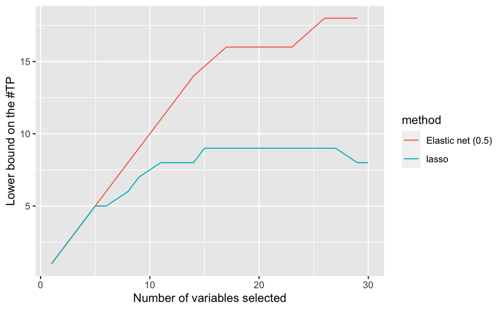

With the same data, we can plot the corresponding upper bound on the False Discovery Proportion:

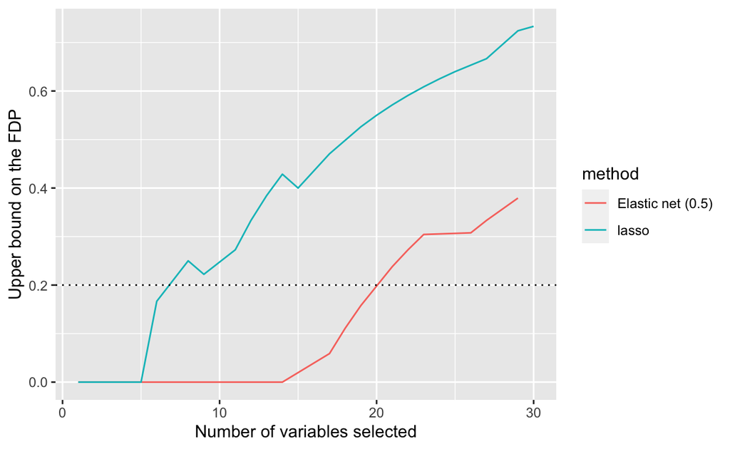

*The fact that the confidence envelope for the FDP is lower for the elastic net does not directly imply that that this method is better than the lasso. It is a consequence of the fact that by construction, the lasso will tend to select only one variable within a group of highly correlated variables, whereas the ridge penalty in the elastic net will allow correlated variables to be selected. Therefore, it is expected that if one retains a fixed number of variables, the lasso will select variables with weaker effects than the elastic net.*

# Adapting to dependence: gains in power by randomization

Just like the BH method for FDR control, the above post hoc bounds rely on the PRDS assumption. In the case of differential gene expression studies, it is generally acknowledged that this assumption is valid. However, we note it is generally not possible to formally prove that is indeed the case for a particular data set. Another caveat is that even in situations where this assumption holds, the corresponding post hoc bounds may be overly conservative.

In order to address these limitations, Blanchard, Neuvial, and Roquain (2020) have proposed to use randomization techniques introduced by Romano and Wolf (2005) and recently refined in Hemerik and Goeman (2018) in order to build bounds that are adaptive to the specific type or intensity of dependence in a particular data set.

In the case of differential expression studies, these methods can be implemented by class label permutation. Intuitively, such permutations cancel the biological signal of differential expression. Importantly, because the same permutation is performed for all genes, the dependence between hypotheses (here, genes) is not affected by the randomization process. Thus performing the same differential analysis after permutation emulates the *joint null distribution* of the test statistics, which makes it possible to calibrate post hoc bounds for a particular data set. This is described in detail in Supplementary section S-5 of Blanchard, Neuvial, and Roquain (2020), and illustrated below. A closely related approach is also proposed in Hemerik, Solari, and Goeman (2019). These methods are also tightly related to the resampling-based techniques popularized by Westfall and Young (1993) in the multiple testing community.

```r
cal <- calibrateJER(dat, B = 1e3, alpha = alpha)
cal$lambda
```

```
      10%
0.1907044
```

In a nutshell, this calibration can be interpreted as follows: for the Chiaretti et al. (2004) data set, at the 90% confidence level, the above post hoc bounds based on the Simes inequality can be applied *for free* at level 0.19 confidence level instead of 0.1. In this particular example, this corresponds to a massive gain in power, due to the fact that the Simes inequality is overly conservative for this particular data set which exhibits substantial positive dependence.

Benjamini, Y., and Y. Hochberg. 1995. “Controlling the False Discovery Rate: A Practical and Powerful Approach to Multiple Testing.” *Journal of the Royal Statistical Society: Series B (Statistical Methodology)* 57 (1): 289–300.

Benjamini, Y., and D. Yekutieli. 2001. “The Control of the False Discovery Rate in Multiple Testing Under Dependency.” *The Annals of Statistics* 29 (4): 1165–88.

Blanchard, Gilles, Pierre Neuvial, and Etienne Roquain. 2019. “On Agnostic Post Hoc Approaches to False Positive Control.” https://hal.archives-ouvertes.fr/hal-02320543.

———. 2020. “Post Hoc Confidence Bounds on False Positives Using Reference Families.” https://arxiv.org/abs/1703.02307.

Chiaretti, Sabina, Xiaochun Li, Robert Gentleman, Antonella Vitale, Marco Vignetti, Franco Mandelli, Jerome Ritz, and Robin Foa. 2004. “Gene Expression Profile of Adult T-Cell Acute Lymphocytic Leukemia Identifies Distinct Subsets of Patients with Different Response to Therapy and Survival.” *Blood* 103 (7). Am Soc Hematology: 2771–8.

Chiaretti, Sabina, Xiaochun Li, Robert Gentleman, Antonella Vitale, Kathy S Wang, Franco Mandelli, Robin Foa, and Jerome Ritz. 2005. “Gene Expression Profiles of B-Lineage Adult Acute Lymphocytic Leukemia Reveal Genetic Patterns That Identify Lineage Derivation and Distinct Mechanisms of Transformation.” *Clinical Cancer Research* 11 (20). AACR: 7209–19.

Genovese, Christopher R, and Larry Wasserman. 2006. “Exceedance Control of the False Discovery Proportion.” *Journal of the American Statistical Association* 101 (476). Taylor & Francis: 1408–17.

Goeman, Jelle J., and Aldo Solari. 2011. “Multiple Testing for Exploratory Research.” *Statist. Sci.* 26 (4): 584–97. https://doi.org/10.1214/11-STS356.

Hemerik, Jesse, and Jelle Goeman. 2018. “Exact Testing with Random Permutations.” *Test* 27 (4). Springer: 811–25.

Hemerik, Jesse, Aldo Solari, and Jelle J Goeman. 2019. “Permutation-Based Simultaneous Confidence Bounds for the False Discovery Proportion.” *Biometrika* 106 (3). Oxford University Press: 635–49.

Romano, Joseph P, and Michael Wolf. 2005. “Exact and Approximate Stepdown Methods for Multiple Hypothesis Testing.” *Journal of the American Statistical Association* 100 (469). Taylor & Francis: 94–108.

Sarkar, Sanat K. 1998. “Some Probability Inequalities for Ordered Mtp2 Random Variables: A Proof of the Simes Conjecture.” *Annals of Statistics*. JSTOR, 494–504.

Simes, R J. 1986. “An Improved Bonferroni Procedure for Multiple Tests of Significance.” *Biometrika* 73 (3). Biometrika Trust: 751–54.

Westfall, Peter H, and S Stanley Young. 1993. *Resampling-Based Multiple Testing: Examples and Methods for P-Value Adjustment*. Vol. 279. John Wiley & Sons.